# Multiple linear least squares regression

GROUP WORK - DEADLINE 15-March-24.  
Please submit your final report [using this form](https://forms.gle/tv1QDTshLHe1zrix6).

[figure not shown]

The [2018 United States Birth Data](https://www.cdc.gov/nchs/nvss/births.htm) were compiled from information on birth certificates by the National Vital Statistics System, part of the National Center for Health Statistics, in cooperation with States ([National Center for Health Statistics 2022](https://bookdown.org/rwnahhas/RMPH/appendix-natality.html#ref-natality_about_2022)). The dataset consists of a random sample from the original dataset, registering births in the United States in the year 2018. Specifically, we will be looking at the following variables:

- DBWT - birth weight (g) 👶. This will be the outcome we will be predicting using a variety of linear regression models
- CIG_REC - smoked during pregnancy 🚭
- risks - risk factors reported
- MAGER - mother’s age 🕗
- MRACEHISP - mother’s race/ethnicity
- DMAR - marital status💍
- MEDUC - mother’s education
- PRIORLIVE - prior births now living
- PRIORDEAD - prior births now dead
- BMI - mother’s body mass index, (kg/m2)

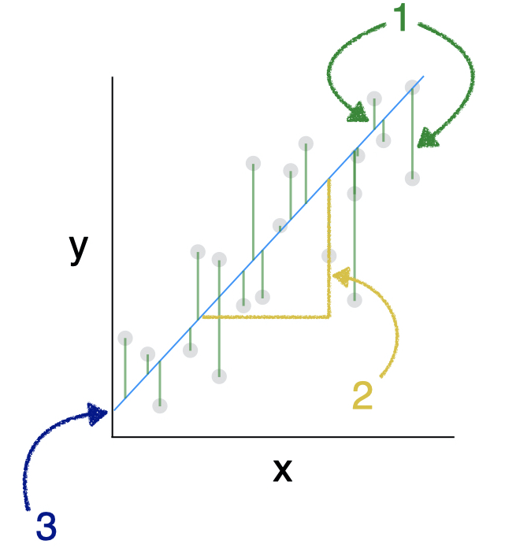

### Creating a reproducible lab report

You will find all the work-space for your lab on posit cloud [using this link](https://posit.cloud/spaces/477804/content/7541657).

We will be using R Markdown to create reproducible lab reports. In RStudio, you will find the file `lab05.Rmd` in the `Files` panel. Double click it to show the script in the code panel.

- In the file, update the YAML with your name, the date and the name of the lab.
- Load the `tidyverse`, `broom`, `table1`, `GGally`, `car`, `easystats`, `datawizard`, `marginaleffects` and the `modelsummary` packages.
- Load the `natality.rds` data set into your workspace, and save it as `natality`.
- Knit your file to see that everything is working.
- For each question, please add the text of the question, the code chunks and your answer.

## Descriptive statistics

1. Use the `table1` package to create a table with appropriate descriptive information about the data set. Use the examples provided in the [following vignette](https://cran.r-project.org/web/packages/table1/vignettes/table1-examples.html) to help you build a table. Feel free to try a different table with other variables. What do you notice from this table? What research questions might it raise?

Maternal demographics stratified by smoking

|  | Non smoker (N=1564) | Smoker (N=124) |
| --- | --- | --- |
| Birth Weight (g) |  |  |
| Mean (SD) | 3250 (601) | 3070 (597) |
| Median [Min, Max] | 3290 [369, 5880] | 3090 [630, 4220] |
| Risk Factors Reported |  |  |
| No | 1088 (69.6%) | 84 (67.7%) |
| Yes | 476 (30.4%) | 40 (32.3%) |
| Mother Age |  |  |
| Mean (SD) | 29.0 (5.79) | 27.8 (5.79) |
| Median [Min, Max] | 29.0 [15.0, 49.0] | 28.0 [17.0, 42.0] |
| Mother Race/Hispanic Origin |  |  |
| NH White | 844 (54.0%) | 94 (75.8%) |
| NH Black | 266 (17.0%) | 14 (11.3%) |
| NH Other | 125 (8.0%) | 10 (8.1%) |
| Hispanic | 329 (21.0%) | 6 (4.8%) |
| Marital Status |  |  |
| Married | 1017 (65.0%) | 40 (32.3%) |
| Unmarried | 547 (35.0%) | 84 (67.7%) |
| Mother Education |  |  |
| lower | 177 (11.3%) | 34 (27.4%) |
| HS | 377 (24.1%) | 45 (36.3%) |
| Some college | 437 (27.9%) | 37 (29.8%) |
| Uni | 573 (36.6%) | 8 (6.5%) |
| Prior births (living) |  |  |
| 0 | 601 (38.4%) | 38 (30.6%) |
| 1 | 516 (33.0%) | 41 (33.1%) |
| 2 | 265 (16.9%) | 17 (13.7%) |
| 3 | 93 (5.9%) | 17 (13.7%) |
| 4+ | 89 (5.7%) | 11 (8.9%) |
| Prior births (dead) |  |  |
| 0 | 1551 (99.2%) | 123 (99.2%) |
| 1+ | 13 (0.8%) | 1 (0.8%) |
| Mother BMI |  |  |
| Mean (SD) | 26.9 (6.32) | 27.3 (6.42) |
| Median [Min, Max] | 25.6 [15.6, 58.4] | 26.3 [16.5, 50.1] |

2. Use the `ggpairs` function to explore the association between the different variables. Try to replicate the figure below, or create your own variation. What do you see in the figure? What new information does it provide? What are the advantages/disadvantages when comparing `table1` to `ggpairs`?

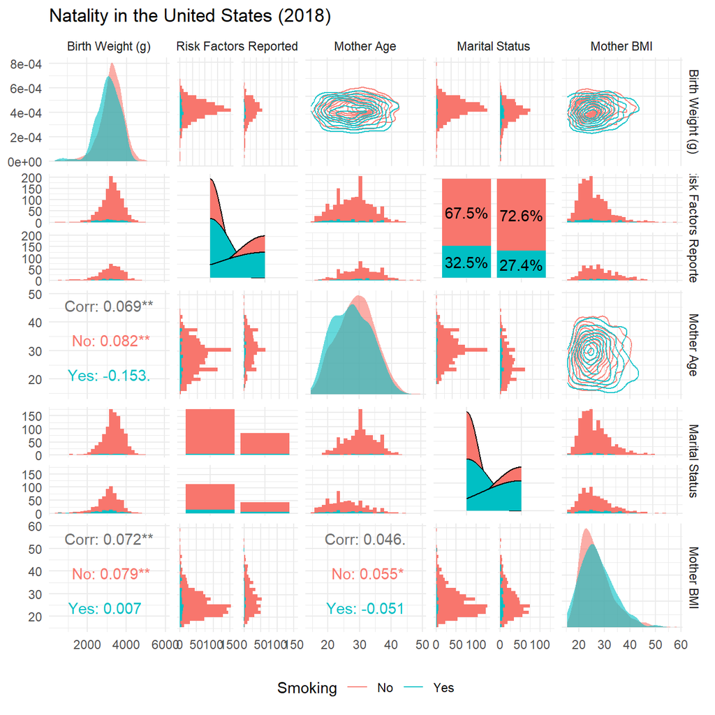